# DataSet Study - Who Suicide 1950-2021

## The objective this scientific article is to analysis the Dataset with world suicide data from 1950 to 2021, remove biases of information, to show the quantity of suicide per country according with the total population and to show others insights that I finded in this Dataset.

## A Small Sumary

### 1. Importing Data

### 2. Treatment of new Dataset columns

### 3. Finding missing data in the Dataset

### 4. Study Dataset Suicide Results from 1950 to 2021

#### 4.1 Total number of suicides related to Men vs. Women

#### 4.2 Graphic Analysis - Total number of suicides per age group

#### 4.3 Graphic Analysis - Suicide quantity vs. total population per countries that appeared per more than 70 years ago in this Dataset

#### 4.4 Graphic Analysis - Suicide quantity vs. total population per countries (All Dataset countries)

#### 4.5 Graphic Analysis - Quantity of suicides per 100.000 inhabitants

#### 4.6 Graphic Analysis - Total number of suicides per year and discrepant behavior in 2020 (Countries that appeared more than 70 years in this Dataset)

#### 4.7 Graphic Analysis - Total number of suicides per year and discrepant behavior in 2020 (All Countries)

#### 4.8 Graphic Analysis - Suicide rate by Generation

#### 4.9 Graphic Analysis - Top 10 Countries with highest growth in suicide rate since the 2000s.

##### 4.9.1 Graphic Analysis - Suicide Rate in the top 10 countries after the 2000s (Analysis by year of each country)

### 1) Importing data.

#### Importanding the bases that are separades for age and sex range.

```python
import pandas            as pd
import numpy             as np
import matplotlib.pyplot as plt

## Data importanding.

# Male suicide data
data_female_5_14  = pd.read_csv(r'C:\Users\Myhost\Desktop\WhoSuicideData(1950-2021)\Data_of_Suicide\Female_5-14.csv')
data_female_15_24 = pd.read_csv(r'C:\Users\Myhost\Desktop\WhoSuicideData(1950-2021)\Data_of_Suicide\Female_15-24.csv')
data_female_25_34 = pd.read_csv(r'C:\Users\Myhost\Desktop\WhoSuicideData(1950-2021)\Data_of_Suicide\Female_25-34.csv')
data_female_35_54 = pd.read_csv(r'C:\Users\Myhost\Desktop\WhoSuicideData(1950-2021)\Data_of_Suicide\Female_35-54.csv')
data_female_55_74 = pd.read_csv(r'C:\Users\Myhost\Desktop\WhoSuicideData(1950-2021)\Data_of_Suicide\Female_55-74.csv')
data_female_GT75  = pd.read_csv(r'C:\Users\Myhost\Desktop\WhoSuicideData(1950-2021)\Data_of_Suicide\Female_75+.csv')
# Female suicide data
data_Male_5_14  = pd.read_csv(r'C:\Users\Myhost\Desktop\WhoSuicideData(1950-2021)\Data_of_Suicide\Male_5-14.csv')
data_Male_15_24 = pd.read_csv(r'C:\Users\Myhost\Desktop\WhoSuicideData(1950-2021)\Data_of_Suicide\Male_15-24.csv')
data_Male_25_34 = pd.read_csv(r'C:\Users\Myhost\Desktop\WhoSuicideData(1950-2021)\Data_of_Suicide\Male_25-34.csv')
data_Male_35_54 = pd.read_csv(r'C:\Users\Myhost\Desktop\WhoSuicideData(1950-2021)\Data_of_Suicide\Male_35-54.csv')
data_Male_55_74 = pd.read_csv(r'C:\Users\Myhost\Desktop\WhoSuicideData(1950-2021)\Data_of_Suicide\Male_55-74.csv')
data_Male_GT75  = pd.read_csv(r'C:\Users\Myhost\Desktop\WhoSuicideData(1950-2021)\Data_of_Suicide\Male_75+.csv')

## Viewing

## Female
display(data_female_5_14)
display(data_female_15_24)
display(data_female_25_34)
display(data_female_35_54)
display(data_female_55_74)
display(data_female_GT75)

## Male
display(data_Male_5_14)
display(data_Male_15_24)
display(data_Male_25_34)
display(data_Male_35_54)
display(data_Male_55_74)
display(data_Male_GT75)
```

|  | Region Code | Region Name | Country Code | Country Name | Year | Sex | Age group code | Age Group | Number | Percentage of cause-specific deaths out of total deaths | Age-standardized death rate per 100 000 standard population | Death rate per 100 000 population |
| --- | --- | --- | --- | --- | --- | --- | --- | --- | --- | --- | --- | --- |
| 0 | EU | Europe | ALB | Albania | 1994 | Female | Age05_09 | [5-9] | 0.0 | 0.000000 | NaN | 0.000000 |
| 1 | EU | Europe | ALB | Albania | 1995 | Female | Age05_09 | [5-9] | 0.0 | 0.000000 | NaN | 0.000000 |
| 2 | EU | Europe | ALB | Albania | 1995 | Female | Age10_14 | [10-14] | 2.0 | 5.000000 | NaN | 1.197605 |
| 3 | EU | Europe | ALB | Albania | 2006 | Female | Age05_09 | [5-9] | 0.0 | 0.000000 | NaN | 0.000000 |
| 4 | EU | Europe | ALB | Albania | 2010 | Female | Age10_14 | [10-14] | 2.0 | 7.692308 | NaN | 1.620404 |
| ... | ... | ... | ... | ... | ... | ... | ... | ... | ... | ... | ... | ... |
| 9437 | NAC | North America and the Caribbean | VCT | Saint Vincent and the Grenadines | 2016 | Female | Age10_14 | [10-14] | 0.0 | 0.000000 | NaN | 0.000000 |
| 9438 | CSA | Central and South America | VEN | Venezuela (Bolivarian Republic of) | 2015 | Female | Age10_14 | [10-14] | 14.0 | 3.571429 | NaN | 1.022218 |
| 9439 | AF | Africa | ZAF | South Africa | 2018 | Female | Age05_09 | [5-9] | 0.0 | 0.000000 | NaN | 0.000000 |
| 9440 | AF | Africa | ZAF | South Africa | 2016 | Female | Age05_09 | [5-9] | 1.0 | 0.074906 | NaN | 0.036007 |
| 9441 | AF | Africa | ZAF | South Africa | 2015 | Female | Age10_14 | [10-14] | 6.0 | 0.436364 | NaN | 0.247416 |

9442 rows × 12 columns

|  | Region Code | Region Name | Country Code | Country Name | Year | Sex | Age group code | Age Group | Number | Percentage of cause-specific deaths out of total deaths | Age-standardized death rate per 100 000 standard population | Death rate per 100 000 population |
| --- | --- | --- | --- | --- | --- | --- | --- | --- | --- | --- | --- | --- |
| 0 | EU | Europe | ALB | Albania | 1988 | Female | Age15_19 | [15-19] | 1.0 | 1.639344 | NaN | 0.660066 |
| 1 | EU | Europe | ALB | Albania | 1994 | Female | Age20_24 | [20-24] | 2.0 | 3.278689 | NaN | 1.490313 |
| 2 | EU | Europe | ALB | Albania | 1995 | Female | Age20_24 | [20-24] | 9.0 | 12.328767 | NaN | 6.696429 |
| 3 | EU | Europe | ALB | Albania | 1997 | Female | Age15_19 | [15-19] | 10.0 | 11.627907 | NaN | 6.468305 |
| 4 | EU | Europe | ALB | Albania | 2000 | Female | Age20_24 | [20-24] | 2.0 | 3.703704 | NaN | 1.598721 |
| ... | ... | ... | ... | ... | ... | ... | ... | ... | ... | ... | ... | ... |
| 9437 | NAC | North America and the Caribbean | VCT | Saint Vincent and the Grenadines | 2018 | Female | Age20_24 | [20-24] | 0.0 | 0.000000 | NaN | 0.000000 |
| 9438 | NAC | North America and the Caribbean | VCT | Saint Vincent and the Grenadines | 2016 | Female | Age20_24 | [20-24] | 0.0 | 0.000000 | NaN | 0.000000 |
| 9439 | NAC | North America and the Caribbean | VCT | Saint Vincent and the Grenadines | 2015 | Female | Age15_19 | [15-19] | 0.0 | 0.000000 | NaN | 0.000000 |
| 9440 | AF | Africa | ZAF | South Africa | 2018 | Female | Age15_19 | [15-19] | 17.0 | 0.631032 | NaN | 0.708165 |
| 9441 | AF | Africa | ZAF | South Africa | 2017 | Female | Age20_24 | [20-24] | 12.0 | 0.238001 | NaN | 0.478894 |

9442 rows × 12 columns

|  | Region Code | Region Name | Country Code | Country Name | Year | Sex | Age group code | Age Group | Number | Percentage of cause-specific deaths out of total deaths | Age-standardized death rate per 100 000 standard population | Death rate per 100 000 population |
| --- | --- | --- | --- | --- | --- | --- | --- | --- | --- | --- | --- | --- |
| 0 | EU | Europe | ALB | Albania | 1987 | Female | Age25_29 | [25-29] | 2.0 | 2.020202 | NaN | 1.435750 |
| 1 | EU | Europe | ALB | Albania | 1987 | Female | Age30_34 | [30-34] | 2.0 | 2.173913 | NaN | 1.696353 |
| 2 | EU | Europe | ALB | Albania | 1988 | Female | Age25_29 | [25-29] | 2.0 | 2.197802 | NaN | 1.407460 |
| 3 | EU | Europe | ALB | Albania | 1988 | Female | Age30_34 | [30-34] | 3.0 | 3.846154 | NaN | 2.493766 |
| 4 | EU | Europe | ALB | Albania | 1989 | Female | Age25_29 | [25-29] | 2.0 | 1.869159 | NaN | 1.386963 |
| ... | ... | ... | ... | ... | ... | ... | ... | ... | ... | ... | ... | ... |
| 9437 | NAC | North America and the Caribbean | VCT | Saint Vincent and the Grenadines | 2018 | Female | Age30_34 | [30-34] | 0.0 | 0.000000 | NaN | 0.000000 |
| 9438 | NAC | North America and the Caribbean | VCT | Saint Vincent and the Grenadines | 2015 | Female | Age25_29 | [25-29] | 0.0 | 0.000000 | NaN | 0.000000 |
| 9439 | CSA | Central and South America | VEN | Venezuela (Bolivarian Republic of) | 2016 | Female | Age30_34 | [30-34] | 10.0 | 0.706215 | NaN | 0.870616 |
| 9440 | AF | Africa | ZAF | South Africa | 2018 | Female | Age25_29 | [25-29] | 11.0 | 0.140306 | NaN | 0.416750 |
| 9441 | AF | Africa | ZAF | South Africa | 2017 | Female | Age30_34 | [30-34] | 14.0 | 0.119781 | NaN | 0.550112 |

9442 rows × 12 columns

|  | Region Code | Region Name | Country Code | Country Name | Year | Sex | Age group code | Age Group | Number | Percentage of cause-specific deaths out of total deaths | Age-standardized death rate per 100 000 standard population | Death rate per 100 000 population |
| --- | --- | --- | --- | --- | --- | --- | --- | --- | --- | --- | --- | --- |
| 0 | EU | Europe | ALB | Albania | 1987 | Female | Age35_39 | [35-39] | 2.0 | 2.222222 | NaN | 2.262443 |
| 1 | EU | Europe | ALB | Albania | 1987 | Female | Age45_49 | [45-49] | 1.0 | 0.806452 | NaN | 1.472754 |
| 2 | EU | Europe | ALB | Albania | 1988 | Female | Age50_54 | [50-54] | 0.0 | 0.000000 | NaN | 0.000000 |
| 3 | EU | Europe | ALB | Albania | 1989 | Female | Age35_39 | [35-39] | 2.0 | 2.150538 | NaN | 2.185792 |
| 4 | EU | Europe | ALB | Albania | 1989 | Female | Age45_49 | [45-49] | 3.0 | 2.500000 | NaN | 4.267425 |
| ... | ... | ... | ... | ... | ... | ... | ... | ... | ... | ... | ... | ... |
| 18879 | CSA | Central and South America | VEN | Venezuela (Bolivarian Republic of) | 2015 | Female | Age45_49 | [45-49] | 7.0 | 0.311526 | NaN | 0.795425 |
| 18880 | AF | Africa | ZAF | South Africa | 2018 | Female | Age50_54 | [50-54] | 4.0 | 0.031807 | NaN | 0.299545 |
| 18881 | AF | Africa | ZAF | South Africa | 2016 | Female | Age40_44 | [40-44] | 5.0 | 0.040880 | NaN | 0.286435 |
| 18882 | AF | Africa | ZAF | South Africa | 2016 | Female | Age50_54 | [50-54] | 6.0 | 0.044613 | NaN | 0.470372 |
| 18883 | AF | Africa | ZAF | South Africa | 2015 | Female | Age45_49 | [45-49] | 6.0 | 0.049830 | NaN | 0.410810 |

18884 rows × 12 columns

|  | Region Code | Region Name | Country Code | Country Name | Year | Sex | Age group code | Age Group | Number | Percentage of cause-specific deaths out of total deaths | Age-standardized death rate per 100 000 standard population | Death rate per 100 000 population |
| --- | --- | --- | --- | --- | --- | --- | --- | --- | --- | --- | --- | --- |
| 0 | EU | Europe | ALB | Albania | 1987 | Female | Age55_59 | [55-59] | 0.0 | 0.000000 | NaN | 0.000000 |
| 1 | EU | Europe | ALB | Albania | 1987 | Female | Age60_64 | [60-64] | 0.0 | 0.000000 | NaN | 0.000000 |
| 2 | EU | Europe | ALB | Albania | 1987 | Female | Age65_69 | [65-69] | 0.0 | 0.000000 | NaN | 0.000000 |
| 3 | EU | Europe | ALB | Albania | 1987 | Female | Age70_74 | [70-74] | 0.0 | 0.000000 | NaN | 0.000000 |
| 4 | EU | Europe | ALB | Albania | 1988 | Female | Age70_74 | [70-74] | 1.0 | 0.148588 | NaN | 4.385965 |
| ... | ... | ... | ... | ... | ... | ... | ... | ... | ... | ... | ... | ... |
| 18879 | NAC | North America and the Caribbean | VCT | Saint Vincent and the Grenadines | 2015 | Female | Age70_74 | [70-74] | 0.0 | 0.000000 | NaN | 0.000000 |
| 18880 | CSA | Central and South America | VEN | Venezuela (Bolivarian Republic of) | 2015 | Female | Age55_59 | [55-59] | 3.0 | 0.076963 | NaN | 0.450834 |
| 18881 | AF | Africa | ZAF | South Africa | 2018 | Female | Age60_64 | [60-64] | 1.0 | 0.006129 | NaN | 0.105966 |
| 18882 | AF | Africa | ZAF | South Africa | 2017 | Female | Age65_69 | [65-69] | 1.0 | 0.005939 | NaN | 0.145982 |
| 18883 | AF | Africa | ZAF | South Africa | 2015 | Female | Age55_59 | [55-59] | 4.0 | 0.028668 | NaN | 0.376958 |

18884 rows × 12 columns

|  | Region Code | Region Name | Country Code | Country Name | Year | Sex | Age group code | Age Group | Number | Percentage of cause-specific deaths out of total deaths | Age-standardized death rate per 100 000 standard population | Death rate per 100 000 population |
| --- | --- | --- | --- | --- | --- | --- | --- | --- | --- | --- | --- | --- |
| 0 | EU | Europe | ALB | Albania | 1987 | Female | Age75_79 | [75-79] | 0.0 | 0.000000 | NaN | 0.000000 |
| 1 | EU | Europe | ALB | Albania | 1987 | Female | Age85_over | [85+] | 1.0 | 0.071839 | NaN | 15.384615 |
| 2 | EU | Europe | ALB | Albania | 1989 | Female | Age75_79 | [75-79] | 0.0 | 0.000000 | NaN | 0.000000 |
| 3 | EU | Europe | ALB | Albania | 1989 | Female | Age85_over | [85+] | 0.0 | 0.000000 | NaN | 0.000000 |
| 4 | EU | Europe | ALB | Albania | 1992 | Female | Age80_84 | [80-84] | 0.0 | 0.000000 | NaN | 0.000000 |
| ... | ... | ... | ... | ... | ... | ... | ... | ... | ... | ... | ... | ... |
| 14158 | NAC | North America and the Caribbean | VCT | Saint Vincent and the Grenadines | 2015 | Female | Age75_79 | [75-79] | 0.0 | 0.000000 | NaN | 0.000000 |
| 14159 | CSA | Central and South America | VEN | Venezuela (Bolivarian Republic of) | 2016 | Female | Age80_84 | [80-84] | 3.0 | 0.037369 | NaN | 2.517074 |
| 14160 | CSA | Central and South America | VEN | Venezuela (Bolivarian Republic of) | 2015 | Female | Age85_over | [85+] | 1.0 | 0.006638 | NaN | 0.985464 |
| 14161 | AF | Africa | ZAF | South Africa | 2016 | Female | Age80_84 | [80-84] | 2.0 | 0.012123 | NaN | 1.106066 |
| 14162 | AF | Africa | ZAF | South Africa | 2015 | Female | Age85_over | [85+] | 0.0 | 0.000000 | NaN | 0.000000 |

14163 rows × 12 columns

|  | Region Code | Region Name | Country Code | Country Name | Year | Sex | Age group code | Age Group | Number | Percentage of cause-specific deaths out of total deaths | Age-standardized death rate per 100 000 standard population | Death rate per 100 000 population |
| --- | --- | --- | --- | --- | --- | --- | --- | --- | --- | --- | --- | --- |
| 0 | EU | Europe | ALB | Albania | 1997 | Male | Age05_09 | [5-9] | 0.0 | 0.000000 | NaN | 0.000000 |
| 1 | EU | Europe | ALB | Albania | 1998 | Male | Age05_09 | [5-9] | 1.0 | 0.826446 | NaN | 0.495786 |
| 2 | EU | Europe | ALB | Albania | 1998 | Male | Age10_14 | [10-14] | 1.0 | 1.149425 | NaN | 0.535619 |
| 3 | EU | Europe | ALB | Albania | 2001 | Male | Age05_09 | [5-9] | 2.0 | 2.272727 | NaN | 1.284802 |
| 4 | NAC | North America and the Caribbean | ATG | Antigua and Barbuda | 1962 | Male | Age05_09 | [5-9] | 0.0 | 0.000000 | NaN | NaN |
| ... | ... | ... | ... | ... | ... | ... | ... | ... | ... | ... | ... | ... |
| 9437 | NAC | North America and the Caribbean | VCT | Saint Vincent and the Grenadines | 2018 | Male | Age10_14 | [10-14] | 0.0 | 0.000000 | NaN | 0.000000 |
| 9438 | NAC | North America and the Caribbean | VCT | Saint Vincent and the Grenadines | 2016 | Male | Age05_09 | [5-9] | 0.0 | 0.000000 | NaN | 0.000000 |
| 9439 | NAC | North America and the Caribbean | VCT | Saint Vincent and the Grenadines | 2016 | Male | Age10_14 | [10-14] | 0.0 | 0.000000 | NaN | 0.000000 |
| 9440 | NAC | North America and the Caribbean | VCT | Saint Vincent and the Grenadines | 2015 | Male | Age05_09 | [5-9] | 0.0 | 0.000000 | NaN | 0.000000 |
| 9441 | NAC | North America and the Caribbean | VCT | Saint Vincent and the Grenadines | 2015 | Male | Age10_14 | [10-14] | 0.0 | 0.000000 | NaN | 0.000000 |

9442 rows × 12 columns

|  | Region Code | Region Name | Country Code | Country Name | Year | Sex | Age group code | Age Group | Number | Percentage of cause-specific deaths out of total deaths | Age-standardized death rate per 100 000 standard population | Death rate per 100 000 population |
| --- | --- | --- | --- | --- | --- | --- | --- | --- | --- | --- | --- | --- |
| 0 | EU | Europe | ALB | Albania | 1994 | Male | Age15_19 | [15-19] | 2.0 | 1.515152 | NaN | 1.493652 |
| 1 | EU | Europe | ALB | Albania | 1997 | Male | Age20_24 | [20-24] | 22.0 | 5.459057 | NaN | 20.239190 |
| 2 | EU | Europe | ALB | Albania | 2000 | Male | Age15_19 | [15-19] | 2.0 | 1.481481 | NaN | 1.501502 |
| 3 | EU | Europe | ALB | Albania | 2001 | Male | Age15_19 | [15-19] | 4.0 | 3.252033 | NaN | 2.760601 |
| 4 | EU | Europe | ALB | Albania | 2002 | Male | Age15_19 | [15-19] | 3.0 | 2.654867 | NaN | 2.011007 |
| ... | ... | ... | ... | ... | ... | ... | ... | ... | ... | ... | ... | ... |
| 9437 | NAC | North America and the Caribbean | VCT | Saint Vincent and the Grenadines | 2017 | Male | Age20_24 | [20-24] | 0.0 | 0.000000 | NaN | 0.000000 |
| 9438 | NAC | North America and the Caribbean | VCT | Saint Vincent and the Grenadines | 2015 | Male | Age15_19 | [15-19] | 0.0 | 0.000000 | NaN | 0.000000 |
| 9439 | NAC | North America and the Caribbean | VCT | Saint Vincent and the Grenadines | 2015 | Male | Age20_24 | [20-24] | 1.0 | 10.000000 | NaN | 23.304591 |
| 9440 | CSA | Central and South America | VEN | Venezuela (Bolivarian Republic of) | 2016 | Male | Age15_19 | [15-19] | 47.0 | 0.988849 | NaN | 3.545824 |
| 9441 | CSA | Central and South America | VEN | Venezuela (Bolivarian Republic of) | 2016 | Male | Age20_24 | [20-24] | 77.0 | 0.922377 | NaN | 6.083566 |

9442 rows × 12 columns

|  | Region Code | Region Name | Country Code | Country Name | Year | Sex | Age group code | Age Group | Number | Percentage of cause-specific deaths out of total deaths | Age-standardized death rate per 100 000 standard population | Death rate per 100 000 population |
| --- | --- | --- | --- | --- | --- | --- | --- | --- | --- | --- | --- | --- |
| 0 | EU | Europe | ALB | Albania | 1987 | Male | Age25_29 | [25-29] | 5.0 | 3.571429 | NaN | 3.367003 |
| 1 | EU | Europe | ALB | Albania | 1988 | Male | Age30_34 | [30-34] | 2.0 | 1.360544 | NaN | 1.557632 |
| 2 | EU | Europe | ALB | Albania | 1989 | Male | Age25_29 | [25-29] | 13.0 | 7.738095 | NaN | 8.469055 |
| 3 | EU | Europe | ALB | Albania | 1992 | Male | Age30_34 | [30-34] | 4.0 | 2.094241 | NaN | 3.202562 |
| 4 | EU | Europe | ALB | Albania | 1995 | Male | Age30_34 | [30-34] | 5.0 | 2.732240 | NaN | 3.930818 |
| ... | ... | ... | ... | ... | ... | ... | ... | ... | ... | ... | ... | ... |
| 9437 | CSA | Central and South America | VEN | Venezuela (Bolivarian Republic of) | 2015 | Male | Age25_29 | [25-29] | 45.0 | 0.841121 | NaN | 3.548303 |
| 9438 | CSA | Central and South America | VEN | Venezuela (Bolivarian Republic of) | 2015 | Male | Age30_34 | [30-34] | 30.0 | 0.716675 | NaN | 2.641138 |
| 9439 | AF | Africa | ZAF | South Africa | 2016 | Male | Age25_29 | [25-29] | 56.0 | 0.417973 | NaN | 2.055328 |
| 9440 | AF | Africa | ZAF | South Africa | 2016 | Male | Age30_34 | [30-34] | 46.0 | 0.265466 | NaN | 1.818459 |
| 9441 | AF | Africa | ZAF | South Africa | 2015 | Male | Age30_34 | [30-34] | 65.0 | 0.402801 | NaN | 2.646161 |

9442 rows × 12 columns

|  | Region Code | Region Name | Country Code | Country Name | Year | Sex | Age group code | Age Group | Number | Percentage of cause-specific deaths out of total deaths | Age-standardized death rate per 100 000 standard population | Death rate per 100 000 population |
| --- | --- | --- | --- | --- | --- | --- | --- | --- | --- | --- | --- | --- |
| 0 | EU | Europe | ALB | Albania | 1987 | Male | Age45_49 | [45-49] | 4.0 | 1.481481 | NaN | 5.398111 |
| 1 | EU | Europe | ALB | Albania | 1987 | Male | Age50_54 | [50-54] | 5.0 | 1.424501 | NaN | 7.788162 |
| 2 | EU | Europe | ALB | Albania | 1988 | Male | Age45_49 | [45-49] | 6.0 | 2.521008 | NaN | 7.947020 |
| 3 | EU | Europe | ALB | Albania | 1988 | Male | Age50_54 | [50-54] | 3.0 | 0.821918 | NaN | 4.580153 |
| 4 | EU | Europe | ALB | Albania | 1989 | Male | Age50_54 | [50-54] | 4.0 | 0.956938 | NaN | 6.024096 |
| ... | ... | ... | ... | ... | ... | ... | ... | ... | ... | ... | ... | ... |
| 18879 | AF | Africa | ZAF | South Africa | 2016 | Male | Age35_39 | [35-39] | 45.0 | 0.262483 | NaN | 2.200117 |
| 18880 | AF | Africa | ZAF | South Africa | 2016 | Male | Age40_44 | [40-44] | 22.0 | 0.123388 | NaN | 1.288322 |
| 18881 | AF | Africa | ZAF | South Africa | 2015 | Male | Age35_39 | [35-39] | 40.0 | 0.234756 | NaN | 2.031370 |
| 18882 | AF | Africa | ZAF | South Africa | 2015 | Male | Age40_44 | [40-44] | 28.0 | 0.159426 | NaN | 1.677110 |
| 18883 | AF | Africa | ZAF | South Africa | 2015 | Male | Age45_49 | [45-49] | 19.0 | 0.111385 | NaN | 1.364351 |

18884 rows × 12 columns

|  | Region Code | Region Name | Country Code | Country Name | Year | Sex | Age group code | Age Group | Number | Percentage of cause-specific deaths out of total deaths | Age-standardized death rate per 100 000 standard population | Death rate per 100 000 population |
| --- | --- | --- | --- | --- | --- | --- | --- | --- | --- | --- | --- | --- |
| 0 | EU | Europe | ALB | Albania | 1987 | Male | Age55_59 | [55-59] | 1.0 | 0.175131 | NaN | 1.945525 |
| 1 | EU | Europe | ALB | Albania | 1987 | Male | Age60_64 | [60-64] | 0.0 | 0.000000 | NaN | 0.000000 |
| 2 | EU | Europe | ALB | Albania | 1988 | Male | Age55_59 | [55-59] | 1.0 | 0.186916 | NaN | 1.908397 |
| 3 | EU | Europe | ALB | Albania | 1988 | Male | Age60_64 | [60-64] | 0.0 | 0.000000 | NaN | 0.000000 |
| 4 | EU | Europe | ALB | Albania | 1988 | Male | Age65_69 | [65-69] | 1.0 | 0.096993 | NaN | 3.225806 |
| ... | ... | ... | ... | ... | ... | ... | ... | ... | ... | ... | ... | ... |
| 18879 | AF | Africa | ZAF | South Africa | 2018 | Male | Age65_69 | [65-69] | 4.0 | 0.019452 | NaN | 0.739790 |
| 18880 | AF | Africa | ZAF | South Africa | 2017 | Male | Age70_74 | [70-74] | 1.0 | 0.006167 | NaN | 0.297423 |
| 18881 | AF | Africa | ZAF | South Africa | 2016 | Male | Age55_59 | [55-59] | 12.0 | 0.058965 | NaN | 1.274278 |
| 18882 | AF | Africa | ZAF | South Africa | 2016 | Male | Age65_69 | [65-69] | 10.0 | 0.049963 | NaN | 2.020022 |
| 18883 | AF | Africa | ZAF | South Africa | 2015 | Male | Age60_64 | [60-64] | 13.0 | 0.062847 | NaN | 1.833162 |

18884 rows × 12 columns

|  | Region Code | Region Name | Country Code | Country Name | Year | Sex | Age group code | Age Group | Number | Percentage of cause-specific deaths out of total deaths | Age-standardized death rate per 100 000 standard population | Death rate per 100 000 population |
| --- | --- | --- | --- | --- | --- | --- | --- | --- | --- | --- | --- | --- |
| 0 | EU | Europe | ALB | Albania | 1987 | Male | Age75_79 | [75-79] | 1.0 | 0.089526 | NaN | 8.064516 |
| 1 | EU | Europe | ALB | Albania | 1987 | Male | Age85_over | [85+] | 0.0 | 0.000000 | NaN | 0.000000 |
| 2 | EU | Europe | ALB | Albania | 1988 | Male | Age80_84 | [80-84] | 0.0 | 0.000000 | NaN | 0.000000 |
| 3 | EU | Europe | ALB | Albania | 1989 | Male | Age75_79 | [75-79] | 2.0 | 0.163265 | NaN | 15.625000 |
| 4 | EU | Europe | ALB | Albania | 1989 | Male | Age85_over | [85+] | 0.0 | 0.000000 | NaN | 0.000000 |
| ... | ... | ... | ... | ... | ... | ... | ... | ... | ... | ... | ... | ... |
| 14158 | NAC | North America and the Caribbean | VCT | Saint Vincent and the Grenadines | 2017 | Male | Age85_over | [85+] | 0.0 | 0.000000 | NaN | 0.000000 |
| 14159 | NAC | North America and the Caribbean | VCT | Saint Vincent and the Grenadines | 2015 | Male | Age75_79 | [75-79] | 0.0 | 0.000000 | NaN | 0.000000 |
| 14160 | CSA | Central and South America | VEN | Venezuela (Bolivarian Republic of) | 2016 | Male | Age80_84 | [80-84] | 8.0 | 0.092060 | NaN | 9.645062 |
| 14161 | AF | Africa | ZAF | South Africa | 2018 | Male | Age75_79 | [75-79] | 2.0 | 0.013700 | NaN | 0.970893 |
| 14162 | AF | Africa | ZAF | South Africa | 2017 | Male | Age80_84 | [80-84] | 2.0 | 0.020809 | NaN | 2.141351 |

14163 rows × 12 columns

#### Joining all the bases and transforming in one

```python
df_to_append_1950_2021 = [data_female_15_24,data_female_25_34,data_female_25_34,data_female_35_54,data_female_55_74,
                          data_female_GT75,data_Male_5_14,data_Male_15_24,data_Male_25_34,data_Male_35_54,data_Male_55_74,
                          data_Male_GT75]

data_female_5_14 = pd.concat([data_female_5_14] + df_to_append_1950_2021, ignore_index=True)
data_female_5_14.to_csv('df_suicide_1950_2021.csv', index=False)
```

#### Viewing the new dataset with all data.

```python
df_suicide_1950_2021 = pd.read_csv(r'C:\Users\Myhost\df_suicide_1950_2021.csv')
df_suicide_1950_2021.head(50)
```

|  | Region Code | Region Name | Country Code | Country Name | Year | Sex | Age group code | Age Group | Number | Percentage of cause-specific deaths out of total deaths | Age-standardized death rate per 100 000 standard population | Death rate per 100 000 population |
| --- | --- | --- | --- | --- | --- | --- | --- | --- | --- | --- | --- | --- |
| 0 | EU | Europe | ALB | Albania | 1994 | Female | Age05_09 | [5-9] | 0.0 | 0.000000 | NaN | 0.000000 |
| 1 | EU | Europe | ALB | Albania | 1995 | Female | Age05_09 | [5-9] | 0.0 | 0.000000 | NaN | 0.000000 |
| 2 | EU | Europe | ALB | Albania | 1995 | Female | Age10_14 | [10-14] | 2.0 | 5.000000 | NaN | 1.197605 |
| 3 | EU | Europe | ALB | Albania | 2006 | Female | Age05_09 | [5-9] | 0.0 | 0.000000 | NaN | 0.000000 |
| 4 | EU | Europe | ALB | Albania | 2010 | Female | Age10_14 | [10-14] | 2.0 | 7.692308 | NaN | 1.620404 |
| 5 | NAC | North America and the Caribbean | ATG | Antigua and Barbuda | 1963 | Female | Age05_09 | [5-9] | 0.0 | 0.000000 | NaN | NaN |
| 6 | NAC | North America and the Caribbean | ATG | Antigua and Barbuda | 1963 | Female | Age10_14 | [10-14] | NaN | NaN | NaN | NaN |
| 7 | NAC | North America and the Caribbean | ATG | Antigua and Barbuda | 1964 | Female | Age05_09 | [5-9] | 0.0 | 0.000000 | NaN | NaN |
| 8 | NAC | North America and the Caribbean | ATG | Antigua and Barbuda | 1964 | Female | Age10_14 | [10-14] | NaN | NaN | NaN | NaN |
| 9 | NAC | North America and the Caribbean | ATG | Antigua and Barbuda | 1966 | Female | Age05_09 | [5-9] | 0.0 | 0.000000 | NaN | 0.000000 |
| 10 | NAC | North America and the Caribbean | ATG | Antigua and Barbuda | 1969 | Female | Age05_09 | [5-9] | 0.0 | 0.000000 | NaN | 0.000000 |
| 11 | NAC | North America and the Caribbean | ATG | Antigua and Barbuda | 1972 | Female | Age10_14 | [10-14] | 0.0 | 0.000000 | NaN | 0.000000 |
| 12 | NAC | North America and the Caribbean | ATG | Antigua and Barbuda | 1974 | Female | Age05_09 | [5-9] | 0.0 | 0.000000 | NaN | 0.000000 |
| 13 | NAC | North America and the Caribbean | ATG | Antigua and Barbuda | 1974 | Female | Age10_14 | [10-14] | 0.0 | 0.000000 | NaN | 0.000000 |
| 14 | NAC | North America and the Caribbean | ATG | Antigua and Barbuda | 1977 | Female | Age10_14 | [10-14] | 0.0 | 0.000000 | NaN | 0.000000 |
| 15 | NAC | North America and the Caribbean | ATG | Antigua and Barbuda | 1983 | Female | Age05_09 | [5-9] | 0.0 | 0.000000 | NaN | NaN |
| 16 | NAC | North America and the Caribbean | ATG | Antigua and Barbuda | 1985 | Female | Age10_14 | [10-14] | 0.0 | 0.000000 | NaN | 0.000000 |
| 17 | NAC | North America and the Caribbean | ATG | Antigua and Barbuda | 1986 | Female | Age10_14 | [10-14] | 0.0 | 0.000000 | NaN | 0.000000 |
| 18 | NAC | North America and the Caribbean | ATG | Antigua and Barbuda | 1988 | Female | Age05_09 | [5-9] | 0.0 | 0.000000 | NaN | 0.000000 |
| 19 | NAC | North America and the Caribbean | ATG | Antigua and Barbuda | 1989 | Female | Age05_09 | [5-9] | 0.0 | 0.000000 | NaN | 0.000000 |
| 20 | EU | Europe | ALB | Albania | 1987 | Female | Age05_09 | [5-9] | 0.0 | 0.000000 | NaN | 0.000000 |
| 21 | EU | Europe | ALB | Albania | 1988 | Female | Age10_14 | [10-14] | 0.0 | 0.000000 | NaN | 0.000000 |
| 22 | EU | Europe | ALB | Albania | 1989 | Female | Age05_09 | [5-9] | 0.0 | 0.000000 | NaN | 0.000000 |
| 23 | EU | Europe | ALB | Albania | 1992 | Female | Age10_14 | [10-14] | 0.0 | 0.000000 | NaN | 0.000000 |
| 24 | EU | Europe | ALB | Albania | 1993 | Female | Age05_09 | [5-9] | 0.0 | 0.000000 | NaN | 0.000000 |
| 25 | EU | Europe | ALB | Albania | 1996 | Female | Age10_14 | [10-14] | 1.0 | 2.040816 | NaN | 0.589623 |
| 26 | EU | Europe | ALB | Albania | 1997 | Female | Age10_14 | [10-14] | 6.0 | 14.285714 | NaN | 3.462204 |
| 27 | EU | Europe | ALB | Albania | 1999 | Female | Age05_09 | [5-9] | 1.0 | 1.351351 | NaN | 0.525486 |
| 28 | EU | Europe | ALB | Albania | 2000 | Female | Age05_09 | [5-9] | 0.0 | 0.000000 | NaN | 0.000000 |
| 29 | EU | Europe | ALB | Albania | 2001 | Female | Age05_09 | [5-9] | 0.0 | 0.000000 | NaN | 0.000000 |
| 30 | EU | Europe | ALB | Albania | 2002 | Female | Age05_09 | [5-9] | 0.0 | 0.000000 | NaN | 0.000000 |
| 31 | EU | Europe | ALB | Albania | 2003 | Female | Age05_09 | [5-9] | 0.0 | 0.000000 | NaN | 0.000000 |
| 32 | EU | Europe | ALB | Albania | 2004 | Female | Age05_09 | [5-9] | 0.0 | 0.000000 | NaN | 0.000000 |
| 33 | EU | Europe | ALB | Albania | 2006 | Female | Age10_14 | [10-14] | 0.0 | 0.000000 | NaN | 0.000000 |
| 34 | EU | Europe | ALB | Albania | 2007 | Female | Age05_09 | [5-9] | 0.0 | 0.000000 | NaN | 0.000000 |
| 35 | NAC | North America and the Caribbean | ATG | Antigua and Barbuda | 1961 | Female | Age10_14 | [10-14] | NaN | NaN | NaN | NaN |
| 36 | NAC | North America and the Caribbean | ATG | Antigua and Barbuda | 1966 | Female | Age10_14 | [10-14] | 0.0 | 0.000000 | NaN | 0.000000 |
| 37 | NAC | North America and the Caribbean | ATG | Antigua and Barbuda | 1969 | Female | Age10_14 | [10-14] | 0.0 | 0.000000 | NaN | 0.000000 |
| 38 | NAC | North America and the Caribbean | ATG | Antigua and Barbuda | 1970 | Female | Age10_14 | [10-14] | 0.0 | 0.000000 | NaN | 0.000000 |
| 39 | NAC | North America and the Caribbean | ATG | Antigua and Barbuda | 1971 | Female | Age10_14 | [10-14] | 0.0 | 0.000000 | NaN | 0.000000 |
| 40 | NAC | North America and the Caribbean | ATG | Antigua and Barbuda | 1975 | Female | Age05_09 | [5-9] | 0.0 | 0.000000 | NaN | 0.000000 |
| 41 | NAC | North America and the Caribbean | ATG | Antigua and Barbuda | 1976 | Female | Age05_09 | [5-9] | 0.0 | 0.000000 | NaN | 0.000000 |
| 42 | EU | Europe | ALB | Albania | 1998 | Female | Age05_09 | [5-9] | 0.0 | 0.000000 | NaN | 0.000000 |
| 43 | EU | Europe | ALB | Albania | 1998 | Female | Age10_14 | [10-14] | 1.0 | 2.631579 | NaN | 0.574053 |
| 44 | EU | Europe | ALB | Albania | 2003 | Female | Age10_14 | [10-14] | 0.0 | 0.000000 | NaN | 0.000000 |
| 45 | EU | Europe | ALB | Albania | 2005 | Female | Age05_09 | [5-9] | 0.0 | 0.000000 | NaN | 0.000000 |
| 46 | EU | Europe | ALB | Albania | 2005 | Female | Age10_14 | [10-14] | 0.0 | 0.000000 | NaN | 0.000000 |
| 47 | EU | Europe | ALB | Albania | 2008 | Female | Age05_09 | [5-9] | 0.0 | 0.000000 | NaN | 0.000000 |
| 48 | EU | Europe | ALB | Albania | 2008 | Female | Age10_14 | [10-14] | 1.0 | 5.263158 | NaN | 0.749777 |
| 49 | EU | Europe | ALB | Albania | 2009 | Female | Age05_09 | [5-9] | 0.0 | 0.000000 | NaN | 0.000000 |

#### Analyzing the dataset structure

```python
df_suicide_1950_2021.info()
```

```
<class 'pandas.core.frame.DataFrame'>
RangeIndex: 169956 entries, 0 to 169955
Data columns (total 12 columns):
 #   Column                                                       Non-Null Count   Dtype
---  ------                                                       --------------   -----
 0   Region Code                                                  169956 non-null  object
 1   Region Name                                                  169956 non-null  object
 2   Country Code                                                 169956 non-null  object
 3   Country Name                                                 169956 non-null  object
 4   Year                                                         169956 non-null  int64
 5   Sex                                                          169956 non-null  object
 6   Age group code                                               169956 non-null  object
 7   Age Group                                                    169956 non-null  object
 8   Number                                                       169000 non-null  float64
 9   Percentage of cause-specific deaths out of total deaths      168457 non-null  float64
 10  Age-standardized death rate per 100 000 standard population  0 non-null       float64
 11  Death rate per 100 000 population                            165160 non-null  float64
dtypes: float64(4), int64(1), object(7)
memory usage: 15.6+ MB
```

#### As we can see, in this dataset there is not a column called "Population Total", therefore, I will import it from another database.

```python
# Searching the data in another base
df_total_pop = pd.read_csv(r'C:\Users\Myhost\Desktop\ReportSuicide\world_population_data.csv')

# Bringing just two colunms this database
df_total_pop2022 = df_total_pop[['Country/Territory', '2022 Population']]

# Displaying 2022 population data for each country.
df_total_pop2022
```

|  | Country/Territory | 2022 Population |
| --- | --- | --- |
| 0 | Afghanistan | 41128771.0 |
| 1 | Albania | 2842321.0 |
| 2 | Algeria | 44903225.0 |
| 3 | American Samoa | 44273.0 |
| 4 | Andorra | 79824.0 |
| ... | ... | ... |
| 229 | Wallis and Futuna | 11572.0 |
| 230 | Western Sahara | 575986.0 |
| 231 | Yemen | 33696614.0 |
| 232 | Zambia | 20017675.0 |
| 233 | Zimbabwe | 16320537.0 |

234 rows × 2 columns

### 2) Treatment of new dataset columns.

### Column "population 2022" being included in the dataset df_suicide_1950_2021

```python
# Renaming of some countries for validation with the new table.

rename_country_totalpop2022 = {
    'Republic of Korea': 'South Korea',
    'Brunei Darussalam': 'Brunei',
    'United States of America': 'United States',
    'Venezuela (Bolivarian Republic of)': 'Venezuela',
    'China, Hong Kong SAR': 'China',
    'Iran (Islamic Republic of)': 'Iran',
    'Republic of Moldova': 'Moldova',
    'R?union': 'Reunion',
    'Russian Federation': 'Russia',
    'Russian': 'Russia',
    'T?rkiye': 'Turkey',
    'Syrian Arab Republic': 'Syria',
    'Czechia':'Czech Republic',
    'Cabo Verde': 'Cape Verde',
    'United Kingdom of Great Britain and Northern Ireland': 'United Kingdom'
}

df_suicide_1950_2021.replace({'Country Name':rename_country_totalpop2022}, inplace=True)

# Joining data in the “2022 population” column according to the name of each country in the dataset

df_suicide_1950_2021_New = pd.merge(
    df_suicide_1950_2021,
    df_total_pop2022[['Country/Territory', '2022 Population']],
    left_on='Country Name',
    right_on='Country/Territory',
    how='left'
)

# Including 2022 population values in some countries that do not receive the base value in the table.

insert_values_countrys = {
    'United States': 338289857,
    'Uruguay': 3422794
}

for country, population in insert_values_countrys.items():
    df_suicide_1950_2021_New.loc[df_suicide_1950_2021_New['Country Name'] == country, '2022 Population'] = population
```

### Searching for null values in the column "2022 Population"

```python
# Checking whether there is an empty "2022 Population" column for any country in the "df_suicide_1950_2021_New".

null_pop2022 = df_suicide_1950_2021_New['2022 Population'].isna()

distinct_countries_population = df_suicide_1950_2021_New.loc[null_pop2022, ['Country Name', '2022 Population']].drop_duplicates('Country Name')

distinct_countries_population
```

|  | Country Name | 2022 Population |
| --- | --- | --- |

### Editing age row - 5 to 9 years.

```python
# Renaming the lines of column Age Group - Converting '[5-9]'  to '[05-09]'

df_suicide_1950_2021_New['Age Group'] = df_suicide_1950_2021_New['Age Group'].replace({'[5-9]': '[05-09]'})

df_suicide_1950_2021_New
```

|  | Region Code | Region Name | Country Code | Country Name | Year | Sex | Age group code | Age Group | Number | Percentage of cause-specific deaths out of total deaths | Age-standardized death rate per 100 000 standard population | Death rate per 100 000 population | Country/Territory | 2022 Population |
| --- | --- | --- | --- | --- | --- | --- | --- | --- | --- | --- | --- | --- | --- | --- |
| 0 | EU | Europe | ALB | Albania | 1994 | Female | Age05_09 | [05-09] | 0.0 | 0.000000 | NaN | 0.000000 | Albania | 2842321.0 |
| 1 | EU | Europe | ALB | Albania | 1995 | Female | Age05_09 | [05-09] | 0.0 | 0.000000 | NaN | 0.000000 | Albania | 2842321.0 |
| 2 | EU | Europe | ALB | Albania | 1995 | Female | Age10_14 | [10-14] | 2.0 | 5.000000 | NaN | 1.197605 | Albania | 2842321.0 |
| 3 | EU | Europe | ALB | Albania | 2006 | Female | Age05_09 | [05-09] | 0.0 | 0.000000 | NaN | 0.000000 | Albania | 2842321.0 |
| 4 | EU | Europe | ALB | Albania | 2010 | Female | Age10_14 | [10-14] | 2.0 | 7.692308 | NaN | 1.620404 | Albania | 2842321.0 |
| ... | ... | ... | ... | ... | ... | ... | ... | ... | ... | ... | ... | ... | ... | ... |
| 169951 | NAC | North America and the Caribbean | VCT | Saint Vincent and the Grenadines | 2017 | Male | Age85_over | [85+] | 0.0 | 0.000000 | NaN | 0.000000 | Saint Vincent and the Grenadines | 103948.0 |
| 169952 | NAC | North America and the Caribbean | VCT | Saint Vincent and the Grenadines | 2015 | Male | Age75_79 | [75-79] | 0.0 | 0.000000 | NaN | 0.000000 | Saint Vincent and the Grenadines | 103948.0 |
| 169953 | CSA | Central and South America | VEN | Venezuela | 2016 | Male | Age80_84 | [80-84] | 8.0 | 0.092060 | NaN | 9.645062 | Venezuela | 28301696.0 |
| 169954 | AF | Africa | ZAF | South Africa | 2018 | Male | Age75_79 | [75-79] | 2.0 | 0.013700 | NaN | 0.970893 | South Africa | 59893885.0 |
| 169955 | AF | Africa | ZAF | South Africa | 2017 | Male | Age80_84 | [80-84] | 2.0 | 0.020809 | NaN | 2.141351 | South Africa | 59893885.0 |

169956 rows × 14 columns

### Creating column for "generation"

```python
# Function development to converter intervalls of age to numeric age values.
def age_converter(interval):
    parts = interval.strip('[]').split('-')

    # Checks if the interval is [85+]
    if len(parts) == 1 and parts[0] == '85+':
        return 85

    start, end = int(parts[0]), int(parts[1])
    return (start + end) / 2

# Function Development to determine the generation with base in the age year.
def determine_generation(year, age):
    # Possibles generations from 1946 to 1964

    if 1946 <= year < 1964:
        if age >= 18:
            return 'Silent Generation'
        else:
            return 'Baby Boomers'

    # Possibles generations from 1964 to 1980

    elif 1964 <= year < 1980:
        if  age >= 40:
            return 'Silent Generation'
        elif age >= 16 and age <= 40:
            return 'Baby Boomers'
        else:
            return 'Generation X'

    # Possibles generations from 1980 to 1997

    elif 1980 <= year < 1997:
        if   age >= 55:
            return 'Silent Generation'
        elif age >= 34 and age <= 55:
            return 'Baby Boomers'
        elif age >= 17 and age <= 34:
            return 'Generation X'
        else:
            return 'Millennial'

    # Possibles generation from 1997 to 2010

    elif 1997 <= year < 2010:
        if   age >= 72:
            return 'Silent Generation'
        elif age >= 51 and age <= 72:
            return 'Baby Boomers'
        elif age >= 33 and age <= 51:
            return 'Generation X'
        elif age >= 17 and age <= 33:
            return 'Millennial'
        elif age <= 17:
            return 'Generation Z'

    # Possibles generation after 2010

    elif year >= 2010:
        if age >= 85:
            return 'Silent Generation'
        elif  age >= 64 and age <= 85:
            return 'Baby Boomers'
        elif age >= 46 and age <= 64:
            return 'Generation X'
        elif age >= 30 and age <= 46:
            return 'Millennial'
        elif age >= 13 and age <= 30:
            return 'Generation Z'
        else:
            return 'Generation Alpha'

# Aplicaning the function in the Dataset "df_suicide_1950_2021_New"
df_suicide_1950_2021_New['Age'] = df_suicide_1950_2021_New['Age Group'].apply(age_converter)
df_suicide_1950_2021_New['Generation'] = df_suicide_1950_2021_New.apply(lambda x: determine_generation(x['Year'], x['Age']), axis=1)
```

### 3) Finding missing data in the dataset

#### Before showing the data objective, I will show the number of countries that appeared in each year of this data frame, which may bring bias to result.

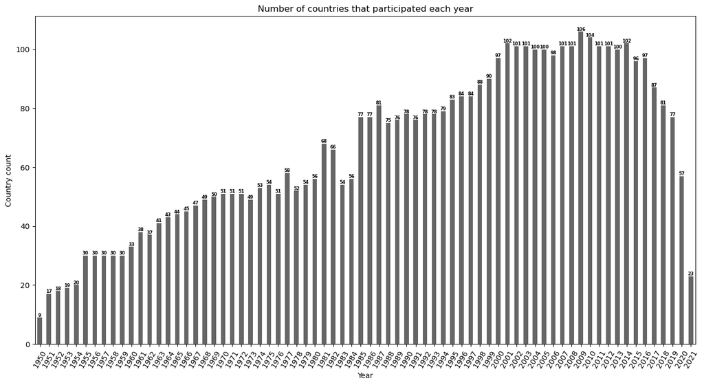

```python
from cycler import cycler
from itertools import cycle


# Get the color palette and rearrange it to start from the final color
colors = list(plt.get_cmap('Dark2').colors)
colors = colors[-1:] + colors[:-1]

# Setting the color cycle
colors_cycler = cycler('color', colors)

# Applying the color cycle to the Matplotlib
plt.rc('axes', prop_cycle=colors_cycler)

# Bars Graphic visualization

plt.figure(figsize=(16,8))

suicides_by_country_year = df_suicide_1950_2021_New.groupby('Year')['Country Name'].nunique()
barras = suicides_by_country_year.plot(kind='bar')

for i, v in enumerate(suicides_by_country_year):
    plt.text(i, v, str(v), ha='center', va='bottom', fontsize=6, fontweight='bold')

plt.xlabel('Year')
plt.ylabel('Country count')
plt.title('Number of countries that participated each year')

plt.xticks(rotation=60)

plt.show()
```

#### As we can see, the majority of countries don't to participate in suicide count, what show that is not possible to make a fair comparison. Therefore, When I count the countries with the highest number of suicides, I will count just the countries that have participated in same amount of years. This way we can avoid biases in the results.

#### Analysing the number of countries per continent in this Dataset.

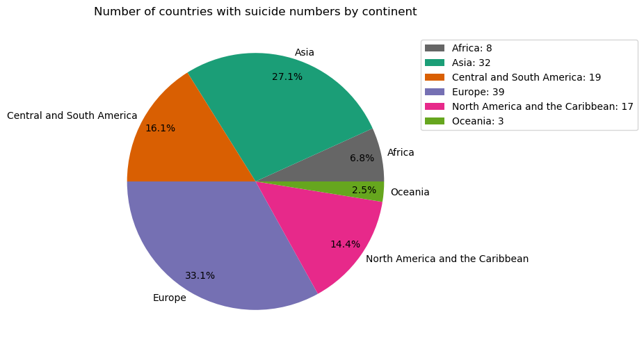

```python
#  Pie Graphic visualization

plt.figure(figsize=(10,6))

suicides_by_region = df_suicide_1950_2021_New.groupby('Region Name')['Country Name'].nunique()

pie = suicides_by_region.plot(kind='pie', autopct='%1.1f%%', pctdistance=0.85, labeldistance=1.05)

plt.legend(suicides_by_region.index.map(lambda x: f'{x}: {suicides_by_region[x]:.0f}'), loc='center left', bbox_to_anchor=(1, 0.8))

plt.title('Number of countries with suicide numbers by continent')

plt.ylabel('')

plt.show()
```

#### In this case, we can also see which countries are missing from the database across all continents, therefore is not possible to compare suicides rates between continents.

#### If we were to count by continent, considering this dataset, the marjority of suicide cases by continent would be from Europe, as shown below, but this data would be biased, due to the dataset fragility.

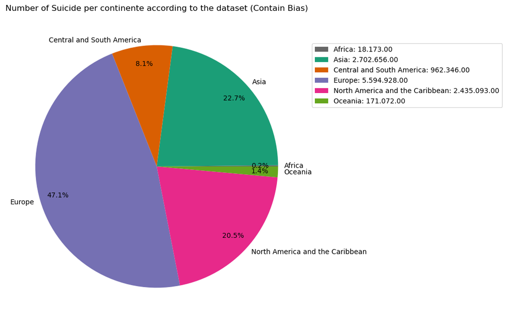

```python
# Pie Graphic visualization

plt.figure(figsize=(12,8))

suicides_by_region = df_suicide_1950_2021_New.groupby('Region Name')['Number'].sum()

pie = suicides_by_region.plot(kind='pie', autopct='%1.1f%%', pctdistance=0.85, labeldistance=1.05)

plt.legend(suicides_by_region.index.map(lambda x: f'{x}: {suicides_by_region[x]:,.2f}'.replace(',', '.')), loc='center left', bbox_to_anchor=(1, 0.8))

plt.title('Number of Suicide per continente according to the dataset (Contain Bias)')

plt.ylabel('')

plt.show()
```

#### Regarding generation data, it will also be necessary to work with a sample, because not all generation participate equally in all dataset years. Considering all data, It's obvious that older generations have a greater representation than new generations, as show below.

#### Number of suicides per generation (Cointain Bias)

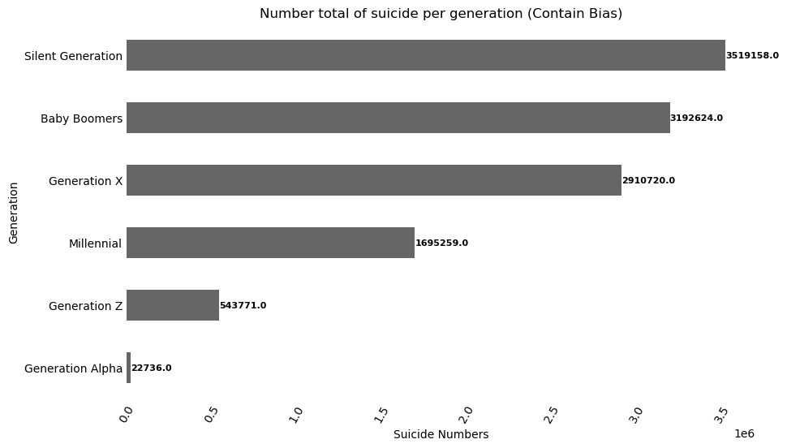

```python
# Bar graphic visualization

plt.figure(figsize=(10,6))

# Group the data by sex and calculate the sum of the numbers of suicides in each group
suicides_by_generation = df_suicide_1950_2021_New.groupby('Generation')['Number'].sum()

suicides_by_generation = suicides_by_generation.sort_values()

# Plot the bar graphic
barras = suicides_by_generation.plot(kind='barh')

for i, v in enumerate(suicides_by_generation ):
    plt.text(v, i, str(v), ha='left', va='center', fontsize=8, fontweight='bold')



# Add labels to axes and title
plt.xlabel('Suicide Numbers')
plt.ylabel('Generation')
plt.title('Number total of suicide per generation (Contain Bias)')

plt.xticks(rotation=60)
plt.box(False)
plt.tick_params(axis='x',length=0)
plt.tick_params(axis='y',length=0)

# Show graphic
plt.show()
```

#### As shown above, we can see that older generations have a higher number of suicides than new generations, due to increased participation in the dataset over the years. After analyzing the missing data in the dataset, I will look for samples when necessary to avoid distortions in the analysis results.

### 4) Study Dataset Suicide Results from 1950 to 2021

#### From now on,I will start analyzing some important results, both considering all data and considering samples (in case of missing data).

#### I will start with a comparison of suicide numbers for Men vs. Women. This way, we can analyze which sex has the highest number of suicide cases.

### 4.1 Graphic Analysis - Total Number of suicides rates - Men vs. Women

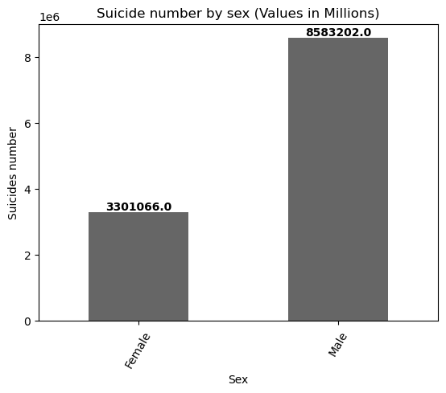

```python
# Bar graphic visualization

# Group the data by sex and calculate the sum of the numbers of suicides in each group
suicides_by_sex = df_suicide_1950_2021_New.groupby('Sex')['Number'].sum()

# Plot the bar graphic
barras = suicides_by_sex.plot(kind='bar')


for i, v in enumerate(suicides_by_sex):
    plt.text(i, v, str(v), ha='center', va='bottom', fontsize=10, fontweight='bold')

# Add labels to axes and title
plt.xlabel('Sex')
plt.ylabel('Suicides number')
plt.title('Suicide number by sex (Values in Millions)')

plt.xticks(rotation=60)

# Show Graphic
plt.show()
```

#### We can see it as a percent in the graphic below.

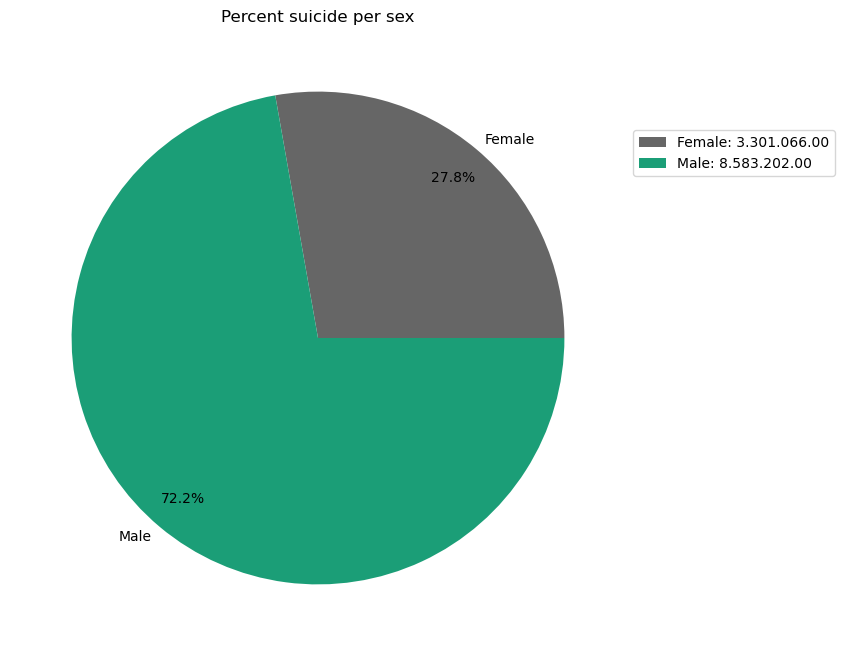

```python
# Pie Graphic visualization

plt.figure(figsize=(12,8))

suicides_by_sex = df_suicide_1950_2021_New.groupby('Sex')['Number'].sum()

pie = suicides_by_sex.plot(kind='pie', autopct='%1.1f%%', pctdistance=0.85, labeldistance=1.05)

plt.legend(suicides_by_sex.index.map(lambda x: f'{x}: {suicides_by_sex[x]:,.2f}'.replace(',', '.')), loc='center left', bbox_to_anchor=(1, 0.8))

plt.title('Percent suicide per sex')

plt.ylabel('')

plt.show()
```

#### In the graph above, we can see that more than 70% of suicide cases are committed by men. We can conclude that for every 10 suicides, 7 are perpetrated by men and 3 are perpetrated by women.

### 4.2 Graphic Analisys - Total Number of suicides per age group

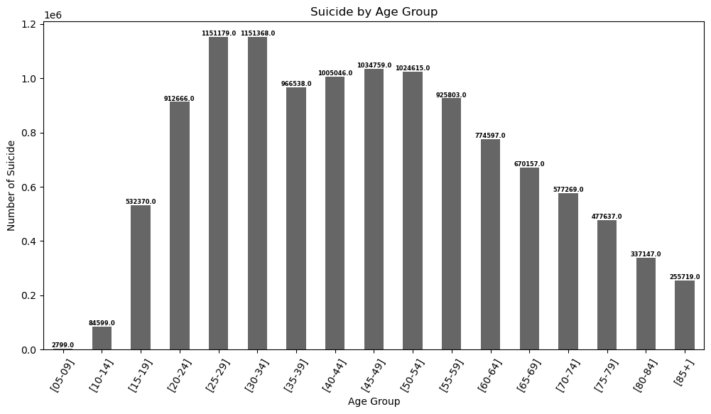

```python
# Bar Graphic Visualization

plt.figure(figsize=(12,6))

suicides_by_agerange = df_suicide_1950_2021_New.groupby('Age Group')['Number'].sum()

barras = suicides_by_agerange.plot(kind='bar')

for i, v in enumerate(suicides_by_agerange):
    plt.text(i, v, str(v), ha='center', va='bottom', fontsize=6, fontweight='bold')

plt.xlabel('Age Group')
plt.ylabel('Number of Suicide')
plt.title('Suicide by Age Group')

plt.xticks(rotation=60)

plt.show()
```